# Reproducible Research: Peer Assessment 2

Impact of Severe Weather Events on Public Health and Economy in the United States

xzw0005

Saturday, July 18, 2015

## Synopsis

In this report, we aim to analyze the impact of different severe weather events on population health as well as economy across the United States. By exploring the U.S. National Oceanic and Atmospheric Administration’s (NOAA) storm database, we conclude that across the United States,:

- **Excessive heat**, **tornado** and **flood** are the most harmful severe weather events with respect to population health, and
- **Flood**, **drought** and **hurricane/typhoon** are among the events which have the greatest economic consequences.

## Data Processing

The data comes from the U.S. National Oceanic and Atmospheric Administration’s (NOAA) storm database. This database tracks characteristics of major storms and weather events in the United States, including when and where they occur, as well as estimates of any fatalities, injuries, and property damage.

```r
if (! "StormData" %in% ls()) {
  if (!file.exists("repdata-data-StormData.csv.bz2")) {
    download.file("https://d396qusza40orc.cloudfront.net/repdata%2Fdata%2FStormData.csv.bz2", destfile = "./repdata-data-StormData.csv.bz2")
  }
  StormData = read.csv(bzfile("repdata-data-StormData.csv.bz2"))
}
str(StormData)
```

```
## 'data.frame':    902297 obs. of  37 variables:
##  $ STATE__   : num  1 1 1 1 1 1 1 1 1 1 ...
##  $ BGN_DATE  : Factor w/ 16335 levels "1/1/1966 0:00:00",..: 6523 6523 4242 11116 2224 2224 2260 383 3980 3980 ...
##  $ BGN_TIME  : Factor w/ 3608 levels "00:00:00 AM",..: 272 287 2705 1683 2584 3186 242 1683 3186 3186 ...
##  $ TIME_ZONE : Factor w/ 22 levels "ADT","AKS","AST",..: 7 7 7 7 7 7 7 7 7 7 ...
##  $ COUNTY    : num  97 3 57 89 43 77 9 123 125 57 ...
##  $ COUNTYNAME: Factor w/ 29601 levels "","5NM E OF MACKINAC BRIDGE TO PRESQUE ISLE LT MI",..: 13513 1873 4598 10592 4372 10094 1973 23873 24418 4598 ...
##  $ STATE     : Factor w/ 72 levels "AK","AL","AM",..: 2 2 2 2 2 2 2 2 2 2 ...
##  $ EVTYPE    : Factor w/ 985 levels "   HIGH SURF ADVISORY",..: 834 834 834 834 834 834 834 834 834 834 ...
##  $ BGN_RANGE : num  0 0 0 0 0 0 0 0 0 0 ...
##  $ BGN_AZI   : Factor w/ 35 levels "","  N"," NW",..: 1 1 1 1 1 1 1 1 1 1 ...
##  $ BGN_LOCATI: Factor w/ 54429 levels "","- 1 N Albion",..: 1 1 1 1 1 1 1 1 1 1 ...
##  $ END_DATE  : Factor w/ 6663 levels "","1/1/1993 0:00:00",..: 1 1 1 1 1 1 1 1 1 1 ...
##  $ END_TIME  : Factor w/ 3647 levels ""," 0900CST",..: 1 1 1 1 1 1 1 1 1 1 ...
##  $ COUNTY_END: num  0 0 0 0 0 0 0 0 0 0 ...
```

[output cut: 23 more lines]

There are 902297 observations with 37 variables in total. The events in the database start in the year 1950 and end in November 2011. In the earlier years of the database there are generally fewer events recorded, most likely due to a lack of good records.

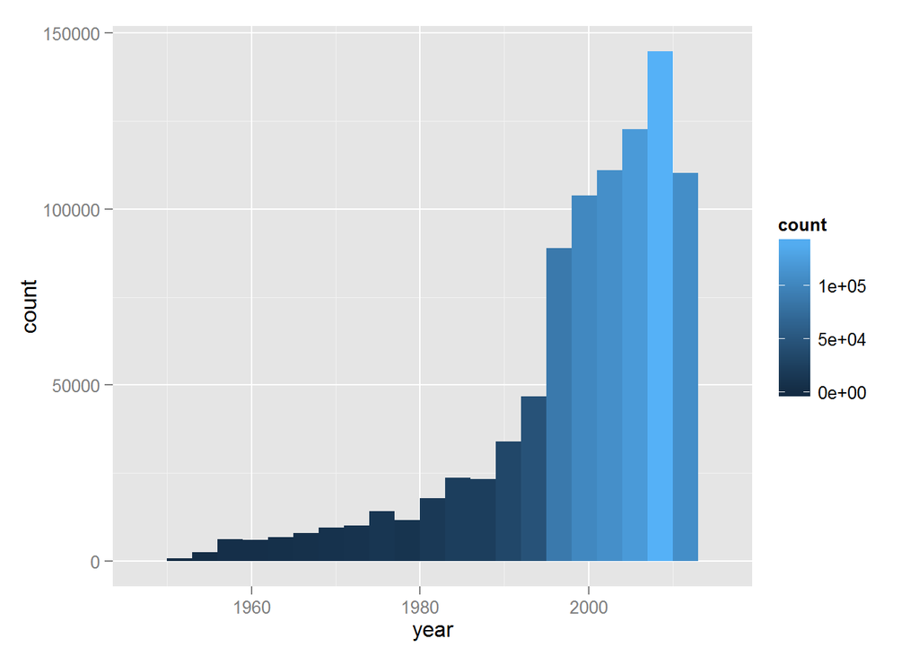

```r
StormData$year <- as.numeric(format(as.Date(StormData$BGN_DATE, format = "%m/%d/%Y %H:%M:%S"), "%Y"))
library(ggplot2)
g = ggplot(StormData, aes(x = year))
g + geom_histogram(binwidth = 3, aes(fill = ..count..))
```

According to the histogram over time, we see that the recorded data significantly increased from the year around 1995. Since more recent years should be considered more complete, we would use the subset of the data since the year 1995.

In this project, we mainly focus on the impact of weather events on population health and economy, thus choose 7 relevant variables, they are:

- **EVTYPE:** Type of event
- **FATALITIES:** Number of fatalities
- **INJURIES:** Number of injuries
- **PROPDMG:** Amount of property damage in orders of magnitude and hence economic damage in USD
- **PROPDMGEXP:** Order of magnitude for property damage (e.g. K for thousands)
- **CROPDMG:** Amount of crop damage in orders of magnitude and hence economic damage in USD
- **CROPDMGEXP:** Order of magnitude for crop damage (e.g. M for millions)

```r
mydata = StormData[StormData$year >= 1995, c("EVTYPE", "FATALITIES", "INJURIES", "PROPDMG", "PROPDMGEXP", "CROPDMG", "CROPDMGEXP")]
str(mydata)
```

```
## 'data.frame':    681500 obs. of  7 variables:
##  $ EVTYPE    : Factor w/ 985 levels "   HIGH SURF ADVISORY",..: 201 629 657 657 410 244 786 786 244 786 ...
##  $ FATALITIES: num  0 0 0 0 2 0 0 0 0 0 ...
##  $ INJURIES  : num  0 0 0 0 0 0 0 0 0 0 ...
##  $ PROPDMG   : num  0 0 0 0 0.1 0 0 0 0 0 ...
##  $ PROPDMGEXP: Factor w/ 19 levels "","-","?","+",..: 1 1 1 1 14 1 1 1 1 1 ...
##  $ CROPDMG   : num  0 0 0 0 10 0 0 0 0 0 ...
##  $ CROPDMGEXP: Factor w/ 9 levels "","?","0","2",..: 1 1 1 1 9 1 1 1 1 1 ...
```

Therefore, we have obtained the much smaller dataset that we will use. The data contains 681500 observations, although the starting year becomes 1995, it still contains more that 75% of the observations. Note that there are 985 factor levels of different event types in the dataset. However, the [National Weather Service Storm Data Documentation](https://d396qusza40orc.cloudfront.net/repdata%2Fpeer2_doc%2Fpd01016005curr.pdf) describes only 48 types of events (see Section 7, “Event Types”, P18-P92). Thus, the event types worth paying much attention. By carefully inspection of the data, we notice that there are several reasons cause so many levels, such as abbreviation, misspelling, different expression, etc. For example, the “FLOOD” might be abbreviated as “FLD”, the “FOG” could be misspelled as “VOG”, the “STORM” might be misspelled as “STROM”, the “AVALANCHE” might be misspelled as “AVALANCE”, the winter weather might be expressed as “WINTER” OR “WINTRY” the “THUNDER” might be spelled as “THUNDER”, “THUNDERE”, etc. At beginning, we are trying to solve this problem by using regular expression. However, the types are quite complicated to deal with. For example, “Marine Thunderstorm Wind” and “Thunderstorm Wind” are totally different types of weather events, where the former is with designator Marine, and the latter is defined as County/Parish (i.e., local). So dealing with the event type names would be our future work.

Another thing needs to be take care of before doing the analysis is that we must take into account the order of magnitude of property damage and crop damage.

```r
unique(mydata$PROPDMGEXP)
```

```
##  [1]   B M K m + 0 5 6 ? 4 2 3 7 H - 1 8
## Levels:  - ? + 0 1 2 3 4 5 6 7 8 B h H K m M
```

```r
unique(mydata$CROPDMGEXP)
```

```
## [1]   M m K B ? 0 k 2
## Levels:  ? 0 2 B k K m M
```

Let H = hundreds, K = thousands, M = millions, B = billions. Then we could obtain the damage values for both property and crop.

```r
mydata$PROPDMGEXP = as.character(mydata$PROPDMGEXP)
mydata$PROPDMGEXP[mydata$PROPDMGEXP == NA] = 0
mydata$PROPDMGEXP[mydata$PROPDMGEXP == "B"] = 9
mydata$PROPDMGEXP[mydata$PROPDMGEXP == "M"] = 6
mydata$PROPDMGEXP[mydata$PROPDMGEXP == "m"] = 6
mydata$PROPDMGEXP[mydata$PROPDMGEXP == "K"] = 3
mydata$PROPDMGEXP[mydata$PROPDMGEXP == "h"] = 2
mydata$PROPDMGEXP[mydata$PROPDMGEXP == "H"] = 2
mydata$PROPDMGEXP[mydata$PROPDMGEXP == ""] = 0
mydata$PROPDMGEXP[mydata$PROPDMGEXP == "+"] = 0
mydata$PROPDMGEXP[mydata$PROPDMGEXP == "-"] = 0
mydata$PROPDMGEXP[mydata$PROPDMGEXP == "?"] = 0

mydata$PropDmgVal = mydata$PROPDMG * (10 ^ as.numeric(mydata$PROPDMGEXP))

mydata$CROPDMGEXP = as.character(mydata$CROPDMGEXP)
mydata$CROPDMGEXP[mydata$CROPDMGEXP == NA] = 0
mydata$CROPDMGEXP[mydata$CROPDMGEXP == ""] = 0
mydata$CROPDMGEXP[mydata$CROPDMGEXP == "?"] = 0
mydata$CROPDMGEXP[mydata$CROPDMGEXP == "B"] = 9
mydata$CROPDMGEXP[mydata$CROPDMGEXP == "M"] = 6
mydata$CROPDMGEXP[mydata$CROPDMGEXP == "m"] = 6
mydata$CROPDMGEXP[mydata$CROPDMGEXP == "K"] = 3
str(mydata)
```

```
## 'data.frame':    681500 obs. of  8 variables:
##  $ EVTYPE    : Factor w/ 985 levels "   HIGH SURF ADVISORY",..: 201 629 657 657 410 244 786 786 244 786 ...
##  $ FATALITIES: num  0 0 0 0 2 0 0 0 0 0 ...
##  $ INJURIES  : num  0 0 0 0 0 0 0 0 0 0 ...
##  $ PROPDMG   : num  0 0 0 0 0.1 0 0 0 0 0 ...
##  $ PROPDMGEXP: chr  "0" "0" "0" "0" ...
##  $ CROPDMG   : num  0 0 0 0 10 0 0 0 0 0 ...
##  $ CROPDMGEXP: chr  "0" "0" "0" "0" ...
##  $ PropDmgVal: num  0e+00 0e+00 0e+00 0e+00 1e+08 0e+00 0e+00 0e+00 0e+00 0e+00 ...
```

```r
mydata$CropDmgVal = mydata$CROPDMG * (10 ^ as.numeric(mydata$CROPDMGEXP))
```